# Missing Data - PhysioNet Sepsis Challenge

efg | 2019-03-03

# 1 Purpose

The purpose of this notebook is to take a preliminary look at the raw data from 5000 patients in the PhysioNet 2019 challenge, where some had sepsis and some did not.

The focus of this notebook is to summarize missing data in

- Demographics data (columns 35-40 in the raw files)
- Outcome variable, `SepsiLabel` (column 41)

# 2 Background

The data being analyzed is from the [Early Prediction of Sepsis from Clinical Data: the PhysioNet/Computing in Cardiology Challenge 2019](https://physionet.org/challenge/2019/).

# 3 Exploration

## 3.1 Setup

```r
plotCaptionLeft  <- "PhysioNet 2019 Sepsis Project"
plotCaptionRight <- paste("efg", format(Sys.time(), "%Y-%m-%d"))
```

### 3.1.1 Packages

```r
library(tidyverse)
library(writexl)
library(kableExtra) # kable_styling
```

### 3.1.2 Helper function

```r
Show <- function(data, caption="", bigMark="", ...)
{
  data                                          %>%
  kable("html",
        caption=caption,
        format.args = list(big.mark=bigMark))   %>%
  kable_styling(bootstrap_options = c("striped", "bordered", "condensed"),
                position = "left", full_width = FALSE, ...)
}
```

### 3.1.3 Load PhysioNet 2019 Challenge Combined Data

```r
load(file = "../../data/PhysioNet-2019-Raw-Data.RData")
dim(allData)
```

```
[1] 188453     42
```

Sample records

```r
allData    %>%
  head(5)  %>%
  Show()
```

| patient | ICULOS | HR | O2Sat | Temp | SBP | MAP | DBP | Resp | EtCO2 | BaseExcess | HCO3 | FiO2 | pH | PaCO2 | SaO2 | AST | BUN | Alkalinephos | Calcium | Chloride | Creatinine | Bilirubin_direct | Glucose | Lactate | Magnesium | Phosphate | Potassium | Bilirubin_total | TroponinI | … |
| --- | --- | --- | --- | --- | --- | --- | --- | --- | --- | --- | --- | --- | --- | --- | --- | --- | --- | --- | --- | --- | --- | --- | --- | --- | --- | --- | --- | --- | --- | --- |
| p00001 | 1 | NA | NA | NA | NA | NA | NA | NA | NA | NA | NA | NA | NA | NA | NA | NA | NA | NA | NA | NA | NA | NA | NA | NA | NA | NA | NA | NA | NA | … |
| p00001 | 2 | 93 | 92.5 | NA | 110 | 76.0 | 56 | 22.0 | NA | NA | NA | NA | NA | NA | NA | NA | NA | NA | NA | NA | NA | NA | NA | NA | NA | NA | NA | NA | NA | … |
| p00001 | 3 | 91 | 96.0 | NA | 108 | 84.5 | 72 | 23.5 | NA | NA | NA | NA | NA | NA | NA | NA | NA | NA | NA | NA | NA | NA | 233 | NA | NA | NA | NA | NA | NA | … |
| p00001 | 4 | 93 | 98.0 | NA | 123 | 87.0 | 61 | 21.0 | NA | NA | NA | NA | NA | NA | NA | NA | NA | NA | NA | NA | NA | NA | NA | NA | NA | NA | NA | NA | NA | … |
| p00001 | 5 | 93 | 95.0 | NA | 110 | 81.0 | 70 | 20.0 | NA | NA | NA | NA | NA | NA | NA | NA | NA | NA | NA | NA | NA | NA | NA | NA | NA | NA | NA | NA | NA | … |

# 4 Global Missing Data Summary

```r
missingCount <- function(x)
{
  sum(is.na(x))
}
```

```r
counts <-
  allData %>%
  summarize_if(is.numeric, missingCount)
```

```r
counts %>%
  Show(bigMark = ",")
```

| ICULOS | HR | O2Sat | Temp | SBP | MAP | DBP | Resp | EtCO2 | BaseExcess | HCO3 | FiO2 | pH | PaCO2 | SaO2 | AST | BUN | Alkalinephos | Calcium | Chloride | Creatinine | Bilirubin_direct | Glucose | Lactate | Magnesium | Phosphate | Potassium | Bilirubin_total | TroponinI | Hct | … |
| --- | --- | --- | --- | --- | --- | --- | --- | --- | --- | --- | --- | --- | --- | --- | --- | --- | --- | --- | --- | --- | --- | --- | --- | --- | --- | --- | --- | --- | --- | --- |
| 0 | 23,092 | 26,800 | 124,968 | 26,544 | 28,235 | 26,582 | 40,261 | 174,788 | 188,043 | 188,126 | 184,229 | 184,272 | 184,267 | 184,929 | 185,081 | 178,062 | 185,061 | 175,602 | 187,291 | 178,050 | 188,016 | 146,609 | 184,941 | 179,496 | 182,960 | 173,991 | 185,054 | 184,910 | 177,514 | … |

Fields always present: ICULOS, Age, Gender, HospAdmTime, SepsisLabel

```r
missingPercent <- function(x)
{
  round(100 * sum(is.na(x)) / length(x), 2)
}
```

```r
percents <-
  allData %>%
  summarize_if(is.numeric, missingPercent)
```

```r
percents %>%
  Show()
```

| ICULOS | HR | O2Sat | Temp | SBP | MAP | DBP | Resp | EtCO2 | BaseExcess | HCO3 | FiO2 | pH | PaCO2 | SaO2 | AST | BUN | Alkalinephos | Calcium | Chloride | Creatinine | Bilirubin_direct | Glucose | Lactate | Magnesium | Phosphate | Potassium | Bilirubin_total | TroponinI | Hct | … |
| --- | --- | --- | --- | --- | --- | --- | --- | --- | --- | --- | --- | --- | --- | --- | --- | --- | --- | --- | --- | --- | --- | --- | --- | --- | --- | --- | --- | --- | --- | --- |
| 0 | 12.25 | 14.22 | 66.31 | 14.09 | 14.98 | 14.11 | 21.36 | 92.75 | 99.78 | 99.83 | 97.76 | 97.78 | 97.78 | 98.13 | 98.21 | 94.49 | 98.2 | 93.18 | 99.38 | 94.48 | 99.77 | 77.8 | 98.14 | 95.25 | 97.09 | 92.33 | 98.2 | 98.12 | 94.2 | … |

```r
percentMissingSummary <-
  tibble(Quantity = names(percents),
         PercentMissingData = as.numeric(percents[1,]))
```

```r
percentMissingSummary  %>%
  Show()
```

| Quantity | PercentMissingData |
| --- | --- |
| ICULOS | 0.00 |
| HR | 12.25 |
| O2Sat | 14.22 |
| Temp | 66.31 |
| SBP | 14.09 |
| MAP | 14.98 |
| DBP | 14.11 |
| Resp | 21.36 |
| EtCO2 | 92.75 |
| BaseExcess | 99.78 |
| HCO3 | 99.83 |
| FiO2 | 97.76 |
| pH | 97.78 |
| PaCO2 | 97.78 |
| SaO2 | 98.13 |
| AST | 98.21 |
| BUN | 94.49 |
| Alkalinephos | 98.20 |
| Calcium | 93.18 |
| Chloride | 99.38 |
| Creatinine | 94.48 |
| Bilirubin_direct | 99.77 |
| Glucose | 77.80 |
| Lactate | 98.14 |
| Magnesium | 95.25 |
| Phosphate | 97.09 |
| Potassium | 92.33 |
| Bilirubin_total | 98.20 |
| TroponinI | 98.12 |
| Hct | 94.20 |
| Hgb | 94.14 |
| PTT | 99.01 |
| WBC | 94.76 |
| Fibrinogen | 99.43 |
| Platelets | 94.68 |
| Age | 0.00 |
| Gender | 0.00 |
| Unit1 | 28.48 |
| Unit2 | 28.48 |
| HospAdmTime | 0.00 |
| SepsisLabel | 0.00 |

# 5 Missing Values % by SepsisLabel

```r
missingPercentBySepsis <-
  allData  %>%
  group_by(SepsisLabel)  %>%
  summarize_if(is.numeric, missingPercent)  %>%
  ungroup()

missingPercentBySepsis %>%
  Show()
```

| SepsisLabel | ICULOS | HR | O2Sat | Temp | SBP | MAP | DBP | Resp | EtCO2 | BaseExcess | HCO3 | FiO2 | pH | PaCO2 | SaO2 | AST | BUN | Alkalinephos | Calcium | Chloride | Creatinine | Bilirubin_direct | Glucose | Lactate | Magnesium | Phosphate | Potassium | Bilirubin_total | TroponinI | … |
| --- | --- | --- | --- | --- | --- | --- | --- | --- | --- | --- | --- | --- | --- | --- | --- | --- | --- | --- | --- | --- | --- | --- | --- | --- | --- | --- | --- | --- | --- | --- |
| 0 | 0 | 12.26 | 14.24 | 66.36 | 14.10 | 15.00 | 14.12 | 21.29 | 93.06 | 99.79 | 99.83 | 97.85 | 97.87 | 97.86 | 98.21 | 98.24 | 94.52 | 98.23 | 93.26 | 99.41 | 94.51 | 99.78 | 77.88 | 98.20 | 95.27 | 97.11 | 92.42 | 98.22 | 98.14 | … |
| 1 | 0 | 11.63 | 12.96 | 62.91 | 13.27 | 13.84 | 13.34 | 26.88 | 70.38 | 99.09 | 99.24 | 91.27 | 91.80 | 91.69 | 92.49 | 96.45 | 91.99 | 96.38 | 87.84 | 97.75 | 91.99 | 99.24 | 71.52 | 93.37 | 93.63 | 95.43 | 85.78 | 96.34 | 96.76 | … |

# 6 Median Patient % Missing

```r
missingPercentByPatient <-
  allData                                   %>%
  select(-ICULOS, -Age, -Gender, -HospAdmTime, -SepsisLabel)  %>%
  group_by(patient)                         %>%
  summarize_if(is.numeric, missingPercent)  %>%
  ungroup()

missingPercentByPatient %>%
  head() %>%
  Show()
```

| patient | HR | O2Sat | Temp | SBP | MAP | DBP | Resp | EtCO2 | BaseExcess | HCO3 | FiO2 | pH | PaCO2 | SaO2 | AST | BUN | Alkalinephos | Calcium | Chloride | Creatinine | Bilirubin_direct | Glucose | Lactate | Magnesium | Phosphate | Potassium | Bilirubin_total | TroponinI | Hct | … |
| --- | --- | --- | --- | --- | --- | --- | --- | --- | --- | --- | --- | --- | --- | --- | --- | --- | --- | --- | --- | --- | --- | --- | --- | --- | --- | --- | --- | --- | --- | --- |
| p00001 | 8.33 | 8.33 | 79.17 | 8.33 | 8.33 | 8.33 | 8.33 | 100 | 100 | 100.00 | 100.00 | 100.00 | 100.00 | 100.00 | 100.00 | 95.83 | 100.00 | 95.83 | 100 | 95.83 | 100.00 | 79.17 | 100.00 | 91.67 | 100.00 | 91.67 | 100.00 | 100.00 | 95.83 | … |
| p00002 | 8.00 | 8.00 | 8.00 | 8.00 | 8.00 | 8.00 | 8.00 | 88 | 100 | 100.00 | 100.00 | 100.00 | 100.00 | 100.00 | 100.00 | 96.00 | 100.00 | 96.00 | 100 | 96.00 | 100.00 | 52.00 | 100.00 | 92.00 | 92.00 | 88.00 | 100.00 | 96.00 | 96.00 | … |
| p00003 | 16.28 | 16.28 | 72.09 | 18.60 | 25.58 | 18.60 | 25.58 | 100 | 100 | 100.00 | 100.00 | 100.00 | 100.00 | 100.00 | 95.35 | 93.02 | 95.35 | 93.02 | 100 | 93.02 | 95.35 | 81.40 | 100.00 | 93.02 | 95.35 | 93.02 | 95.35 | 93.02 | 95.35 | … |
| p00004 | 3.39 | 5.08 | 76.27 | 6.78 | 6.78 | 6.78 | 15.25 | 100 | 100 | 100.00 | 100.00 | 100.00 | 100.00 | 100.00 | 100.00 | 100.00 | 100.00 | 100.00 | 100 | 100.00 | 100.00 | 100.00 | 100.00 | 100.00 | 100.00 | 100.00 | 100.00 | 100.00 | 100.00 | … |
| p00005 | 15.38 | 15.38 | 63.46 | 17.31 | 21.15 | 17.31 | 19.23 | 100 | 100 | 100.00 | 98.08 | 96.15 | 96.15 | 96.15 | 98.08 | 90.38 | 98.08 | 86.54 | 100 | 90.38 | 100.00 | 78.85 | 96.15 | 92.31 | 98.08 | 86.54 | 98.08 | 92.31 | 90.38 | … |
| p00006 | 42.55 | 42.55 | 82.98 | 42.55 | 46.81 | 42.55 | 42.55 | 100 | 100 | 95.74 | 100.00 | 100.00 | 95.74 | 95.74 | 97.87 | 93.62 | 97.87 | 93.62 | 100 | 93.62 | 100.00 | 82.98 | 100.00 | 95.74 | 97.87 | 89.36 | 97.87 | 100.00 | 89.36 | … |

Median patient percent missing

```r
medianPatientPercentMissing <-
  missingPercentByPatient  %>%
  summarize_if(is.numeric, median)

medianPatientPercentMissing  %>%
  Show()
```

| HR | O2Sat | Temp | SBP | MAP | DBP | Resp | EtCO2 | BaseExcess | HCO3 | FiO2 | pH | PaCO2 | SaO2 | AST | BUN | Alkalinephos | Calcium | Chloride | Creatinine | Bilirubin_direct | Glucose | Lactate | Magnesium | Phosphate | Potassium | Bilirubin_total | TroponinI | Hct | Hgb | … |
| --- | --- | --- | --- | --- | --- | --- | --- | --- | --- | --- | --- | --- | --- | --- | --- | --- | --- | --- | --- | --- | --- | --- | --- | --- | --- | --- | --- | --- | --- | --- |
| 7.41 | 8.33 | 75.76 | 8.7 | 9.09 | 8.7 | 14.89 | 100 | 100 | 100 | 100 | 100 | 100 | 100 | 100 | 94.87 | 100 | 94.44 | 100 | 94.87 | 100 | 80.95 | 100 | 95.45 | 97.62 | 93.94 | 100 | 100 | 94.87 | 94.87 | … |

Transpose for better summary table

```r
percentMissingSummary <-
  tibble(Quantity = names(medianPatientPercentMissing),
         MedianPatientPercentMissing = as.numeric(medianPatientPercentMissing[1,]))
```

```r
percentMissingSummary %>%
  Show()
```

| Quantity | MedianPatientPercentMissing |
| --- | --- |
| HR | 7.41 |
| O2Sat | 8.33 |
| Temp | 75.76 |
| SBP | 8.70 |
| MAP | 9.09 |
| DBP | 8.70 |
| Resp | 14.89 |
| EtCO2 | 100.00 |
| BaseExcess | 100.00 |
| HCO3 | 100.00 |
| FiO2 | 100.00 |
| pH | 100.00 |
| PaCO2 | 100.00 |
| SaO2 | 100.00 |
| AST | 100.00 |
| BUN | 94.87 |
| Alkalinephos | 100.00 |
| Calcium | 94.44 |
| Chloride | 100.00 |
| Creatinine | 94.87 |
| Bilirubin_direct | 100.00 |
| Glucose | 80.95 |
| Lactate | 100.00 |
| Magnesium | 95.45 |
| Phosphate | 97.62 |
| Potassium | 93.94 |
| Bilirubin_total | 100.00 |
| TroponinI | 100.00 |
| Hct | 94.87 |
| Hgb | 94.87 |
| PTT | 100.00 |
| WBC | 95.00 |
| Fibrinogen | 100.00 |
| Platelets | 95.00 |
| Unit1 | 0.00 |
| Unit2 | 0.00 |

# 7 Sample Missingness Maps

Exclude variables always defined

## 7.1 Sepsis Patient

Example of a patient with sepsis indicated in first hour and all subsequent hours.

```r
library(Amelia)
sampleSepsisPatient <-
  allData                        %>%
  filter(patient == "p01072")    %>%
  select(-patient, -ICULOS, -Age, -Gender, -HospAdmTime, -SepsisLabel)

dim(sampleSepsisPatient)
```

```
## [1] 10 36
```

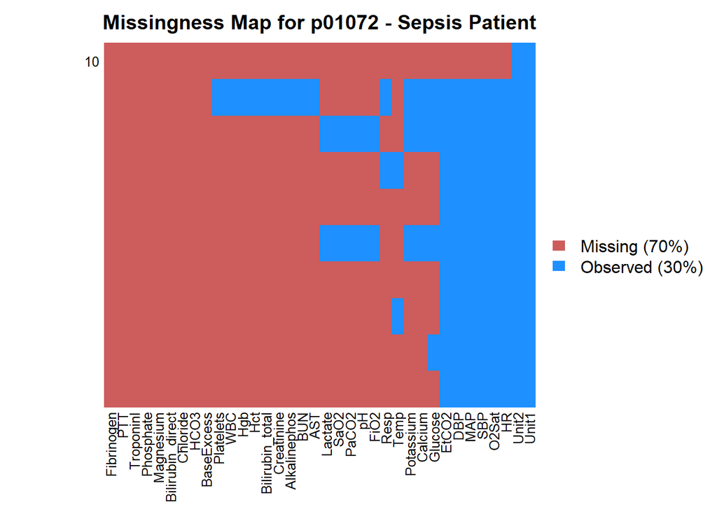

```r
missmap(sampleSepsisPatient,
        main = "Missingness Map for p01072 - Sepsis Patient")
```

## 7.2 Non-Sepsis Patient

```r
samplePatient <-
  allData                      %>%
  filter(patient == "p00003")  %>%
  select(-patient, -ICULOS, -Age, -Gender, -HospAdmTime, -SepsisLabel)

dim(samplePatient)
```

```
## [1] 43 36
```

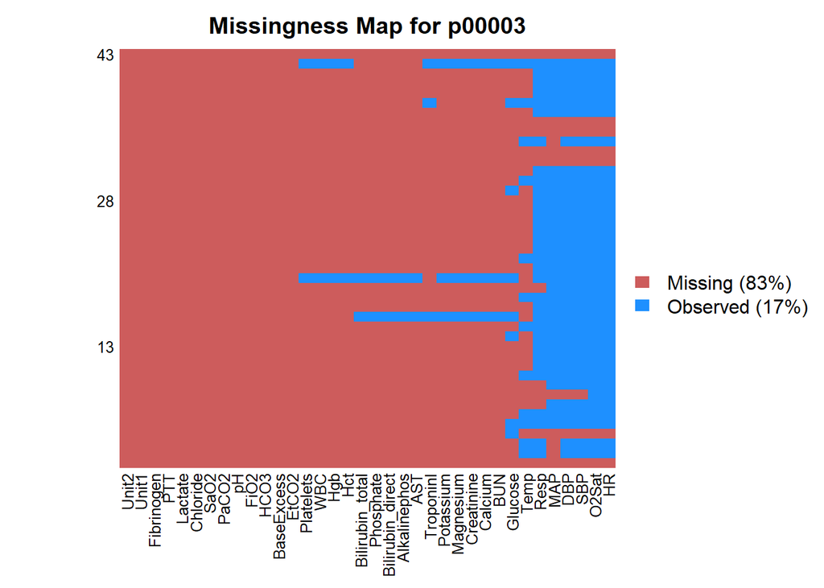

```r
missmap(samplePatient,
        main = "Missingness Map for p00003")
```

# 8 Discussion

When combined into a single dataset, the 5000 files contain 188,453 records with 42 fields.

Fields always present: ICULOS, Age, Gender, HospAdmTime, SepsisLabel

Fields with < 15% missing values: HR, O2Sat, SBP, MAP, DBP

Fields with 20% to 90% missing: Temp, Resp, Glucose, Unit1, Unit2

All other fields have > 90% missing values.

The stats by patient are not encouraging either. The median patient percent missing is 100% for 16 of the quantities.

# 9 Conclusions

Are there are too many missing values for meaningful analysis of this data?

Maybe.

Processing time: 4.3 secs

2019-03-10 2254